# Forecasting San Diego Power Consumption

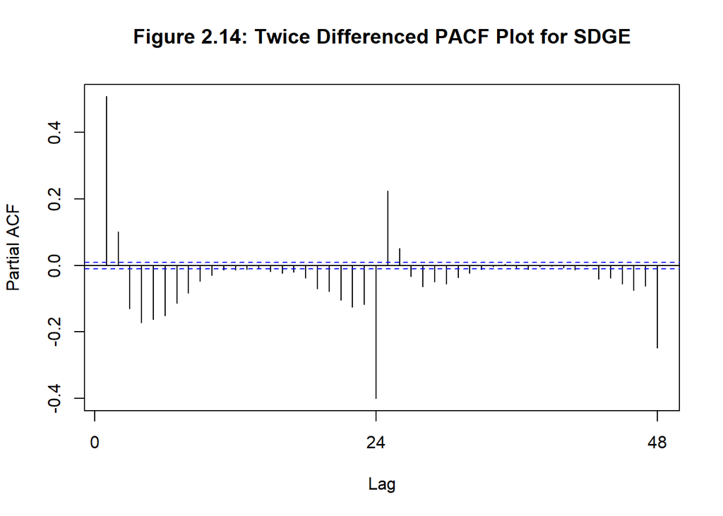

```r
SD_ts %>% diff(lag = 24) %>% diff() %>% Pacf(main = "Figure 2.14: Twice Differenced PACF Plot for SDGE")
```

Fit model - Acf shows strong MA(1) for non-seasonal and seasonal on twice differenced chart, same story with Pacf for our AR(p) component. We took a non-seasonal and seasonal difference so we’ll train a ARIMA(1,1,1)(1,1,1) model

```r
seasonal_arima <- Arima(y_tr, order=c(1,1,1), seasonal = c(1,1,1), xreg=X_tr)
summary(seasonal_arima)
```

```
## Series: y_tr
## Regression with ARIMA(1,1,1) errors
##
## Coefficients:
##          ar1      ma1  HourlyWetBulbTemperature  HourlyStationPressure
##       0.6354  -0.0906                    2.5471              1323.3350
## s.e.  0.0058   0.0070                    0.4177                45.7668
##
## sigma^2 = 9238:  log likelihood = -231185
## AIC=462380   AICc=462380   BIC=462422.8
##
## Training set error measures:
##                      ME    RMSE      MAE        MPE     MAPE      MASE
## Training set 0.01162238 96.1095 73.41905 0.06089286 3.415765 0.8227883
##                      ACF1
## Training set -0.009848838
```

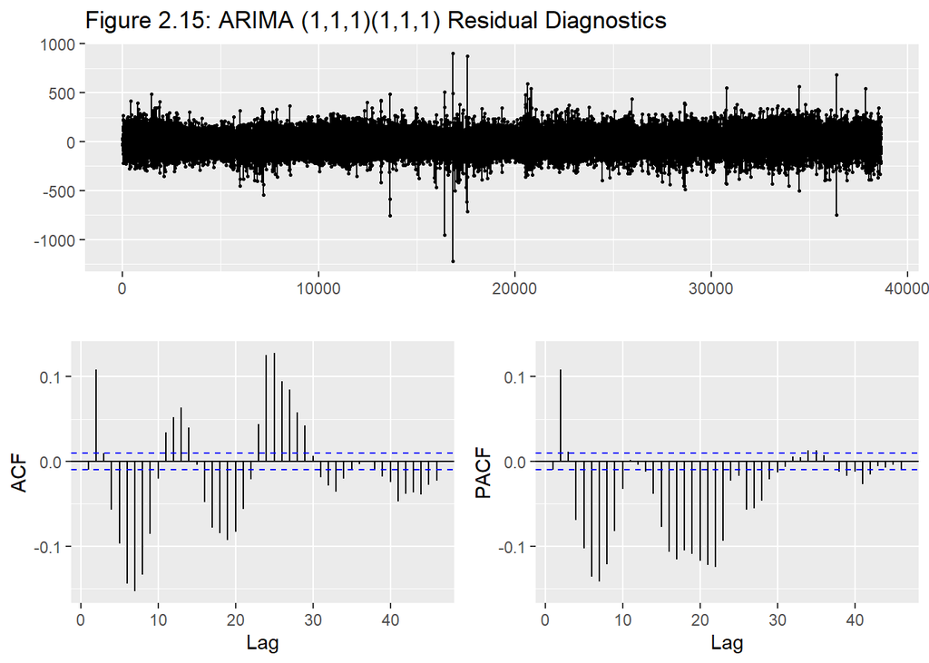

```r
seasonal_arima %>% residuals() %>% ggtsdisplay(main = "Figure 2.15: ARIMA (1,1,1)(1,1,1) Residual Diagnostics")
```

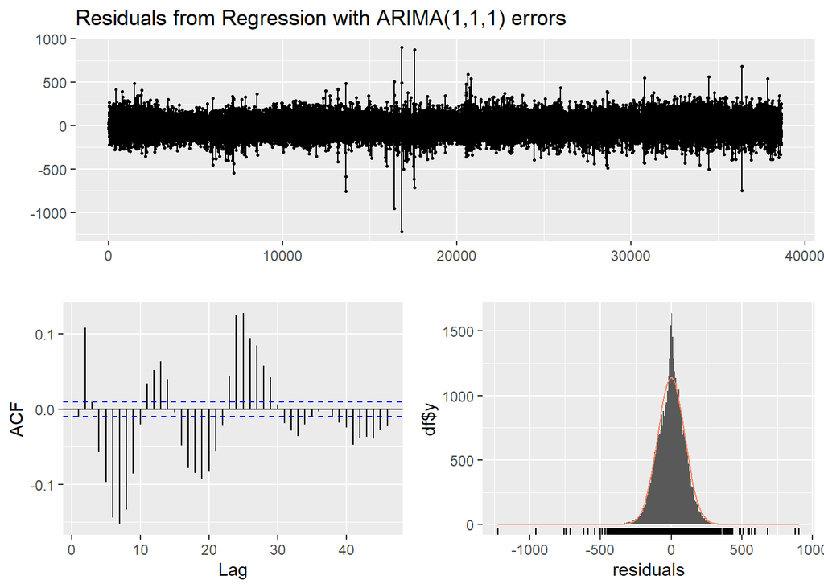

```
##
##  Ljung-Box test
##
## data:  Residuals from Regression with ARIMA(1,1,1) errors
## Q* = 3654, df = 8, p-value < 2.2e-16
##
## Model df: 2.   Total lags used: 10
```

```r
seasonal_arima %>% checkresiduals()
```

Continue to tune - Definitely didn’t include enough components, we’ll keep playing around until we find good values. (3,1,3) looks good for non-seasonal components.

```r
seasonal_arima_tuned <- Arima(y_tr, order=c(3,1,3), seasonal = c(2,1,2), xreg=X_tr)
summary(seasonal_arima_tuned)
```

```
## Series: y_tr
## Regression with ARIMA(3,1,3) errors
##
## Coefficients:
##          ar1      ar2     ar3      ma1     ma2      ma3
##       2.2965  -1.8639  0.5242  -1.8953  1.2200  -0.3198
## s.e.  0.0194   0.0339  0.0164   0.0202  0.0287   0.0101
##       HourlyWetBulbTemperature  HourlyStationPressure
##                         4.5467               400.5317
## s.e.                    0.4046                38.9464
##
## sigma^2 = 7882:  log likelihood = -228118.6
## AIC=456255.3   AICc=456255.3   BIC=456332.3
##
## Training set error measures:
##                     ME     RMSE      MAE        MPE     MAPE      MASE
## Training set 0.1581167 88.77287 67.47707 -0.1363844 3.145751 0.7561981
##                     ACF1
## Training set 0.007017214
```

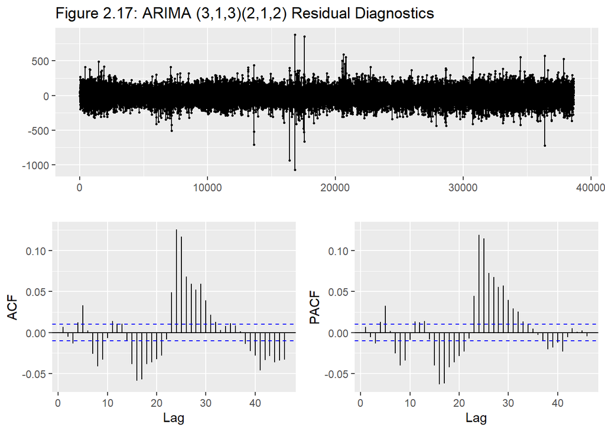

```r
seasonal_arima_tuned %>% residuals() %>% ggtsdisplay(main = "Figure 2.17: ARIMA (3,1,3)(2,1,2) Residual Diagnostics")
```

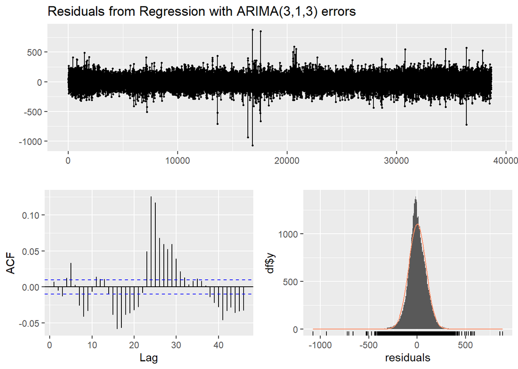

```
##
##  Ljung-Box test
##
## data:  Residuals from Regression with ARIMA(3,1,3) errors
## Q* = 195.89, df = 4, p-value < 2.2e-16
##
## Model df: 6.   Total lags used: 10
```

```r
seasonal_arima_tuned %>% checkresiduals()
```

Forecast, Calculate RMSE, and Plot

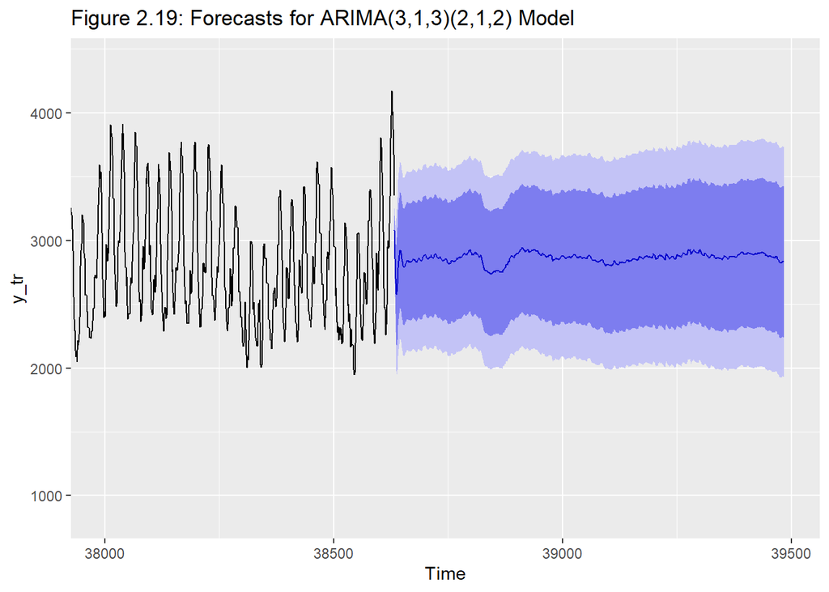

```r
seasonal_forecast <- forecast(seasonal_arima_tuned, xreg = X_val)

#RMSE
val_forecast_err <- SD_val$SDGE - seasonal_forecast$mean
seasonal_arima_rmse_val <- sqrt(mean(val_forecast_err^2))
seasonal_arima_rmse_tr <- sqrt(mean(seasonal_arima_tuned$residuals^2))

#plot
autoplot(seasonal_forecast, series = "Forecast") +
  coord_cartesian(xlim = c(38000, 39488)) +
  ggtitle("Figure 2.19: Forecasts for ARIMA(3,1,3)(2,1,2) Model")
```

## Neural Network

```r
#size= (p+p+1)/2 = (3+2+1)/2 =3
set.seed(123)
SD_NN <- nnetar(y_tr_ts, p=3, P=2, size =3, xreg = X_tr)
```

```r
#prediction
SD_NN.pred<-forecast(SD_NN, xreg = X_val)

# Not sure why but this prints out the entire data frame of forecasts, won't output to reduce appendix clutter.
#summary(SD_NN.pred)
```

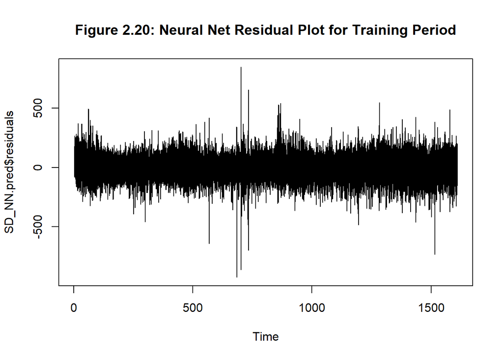

```r
# Plot the errors for the training period
plot(SD_NN.pred$residuals, main = "Figure 2.20: Neural Net Residual Plot for Training Period")
```

```r
#Accuracy & Plot
accuracy(SD_NN.pred, y_test)
```

```
##                       ME      RMSE       MAE        MPE      MAPE      MASE
## Training set  0.05947569  84.47837  63.86467 -0.1675212  2.996544 0.7157148
## Test set     59.74111315 430.80023 337.86279  0.7793615 11.949428 3.7863409
##                      ACF1
## Training set -0.001513646
## Test set               NA
```

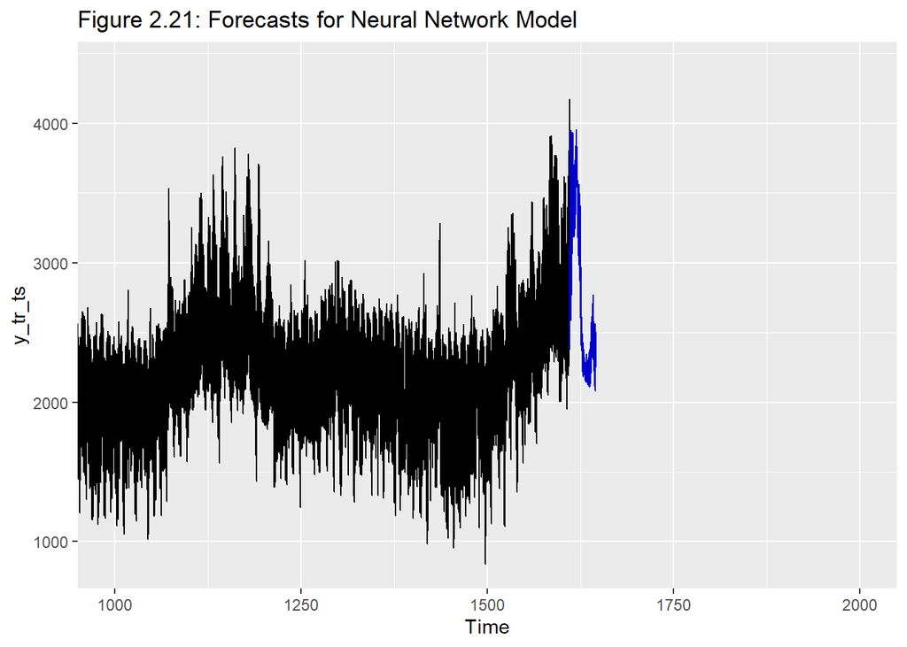

```r
autoplot(SD_NN.pred, series = "Forecast") +
  coord_cartesian(xlim = c(1000, 2000)) +
  ggtitle("Figure 2.21: Forecasts for Neural Network Model")
```

Get metrics

```r
nnetar_rmse_tr <- sqrt(mean(SD_NN$residuals^2, na.rm = TRUE))
val_forecast_err <- SD_val$SDGE - SD_NN.pred$mean
nnetar_rmse_val <- sqrt(mean(val_forecast_err^2))
```

## avNNet

Not included in final but leaving for future reference/discussion

```r
modelFit <- avNNet(X_tr,
                   y_tr,
                   size = 5,
                   linout = TRUE,
                   trace = FALSE)
summary(modelFit)

nnpred1 <- predict(modelFit, X_val)
```

```r
accuracy(nnpred1, y_test)
```

## Regression

Also not included in final but left for reference.

Based on our time series, it looks like we have additive seasonality with no trend.

```r
SD_reg_addseason <- tslm(y_tr_ts ~ season)
SD_reg_addseason_pred <- forecast(SD_reg_addseason, h = length(y_val_ts))
```

Forecast, Calculate RMSE, and Plot

```r
reg_forecast <- forecast(SD_reg_addseason, h=length(y_test))

#RMSE
val_forecast_err <- SD_val$SDGE - reg_forecast$mean
reg_rmse_val <- sqrt(mean(val_forecast_err^2))
reg_rmse_tr <- sqrt(mean(SD_reg_addseason$residuals^2))

#plot
autoplot(reg_forecast, series = "Forecast") +
  coord_cartesian(xlim = c(1550, 1650)) +
  ggtitle("Figure 2.7: Forecasts from Linear Regression Model")
```

# Section 3 - Results

Create Results df

```r
Model <- c("Naive", "2-Hour MA", "Auto ARIMA", "Manual ARIMA", "Seasonal ARIMA", "ETS", "Neural Net.")
Tr_RMSE <- c(Naive_rmse_tr, MA_rmse_tr, auto_arima_rmse_tr, manual_arima_rmse_tr, seasonal_arima_rmse_tr, ets_rmse_tr, nnetar_rmse_tr)
Val_RMSE <- c(Naive_rmse_val, MA_rmse_val, auto_arima_rmse_val, manual_arima_rmse_val, seasonal_arima_rmse_val, ets_rmse_val, nnetar_rmse_val)

Results_df <- data.frame(Model, Tr_RMSE, Val_RMSE)

Results_df <- Results_df %>% mutate(BaselineComp_tr = ifelse(Tr_RMSE == Naive_rmse_tr, "Baseline", ifelse(Tr_RMSE < Naive_rmse_tr, "Better", "Worse")))
Results_df <- Results_df %>% mutate(BaselineComp_val = ifelse(Val_RMSE == Naive_rmse_val, "Baseline", ifelse(Val_RMSE < Naive_rmse_val, "Better", "Worse")))

Results_df <- Results_df %>% mutate_if(is.character, as.factor)
```

Plot Training RMSE’s

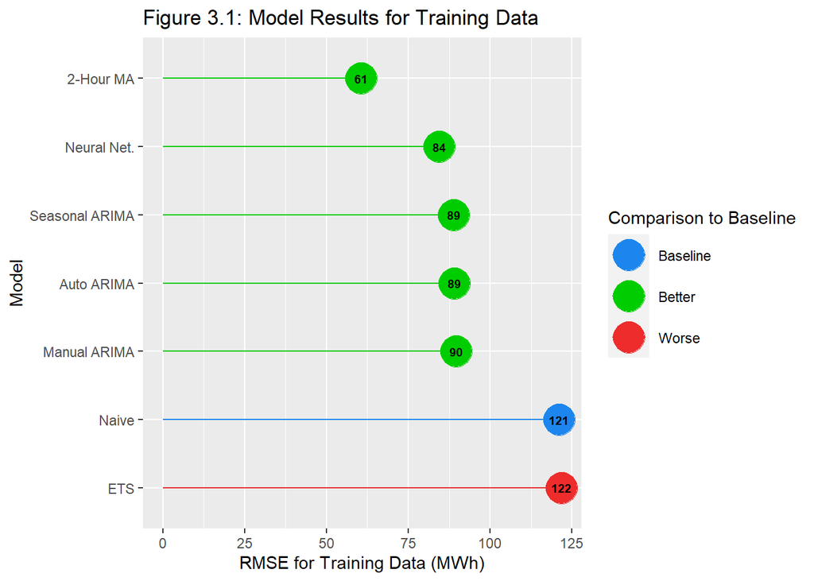

```r
ggplot(Results_df, aes(x = reorder(Model, -Tr_RMSE), y = Tr_RMSE, color = BaselineComp_tr)) +
  geom_segment(aes(x=reorder(Model, -Tr_RMSE), xend = reorder(Model, -Tr_RMSE), y = 0, yend = Tr_RMSE)) +
  scale_color_manual(values = c("dodgerblue2", "green3", "firebrick2")) +
  geom_point(size = 9) + coord_flip() + labs(color = "Comparison to Baseline") +
  ylab("RMSE for Training Data (MWh)") + ggtitle("Figure 3.1: Model Results for Training Data") + xlab("Model") + geom_text(aes(label = round(Tr_RMSE)), color = "black", size = 2.5, fontface = "bold")
```

Plot Validation RMSE’s - Reordering isn’t working when I flip coordinates. Need to find workaround.

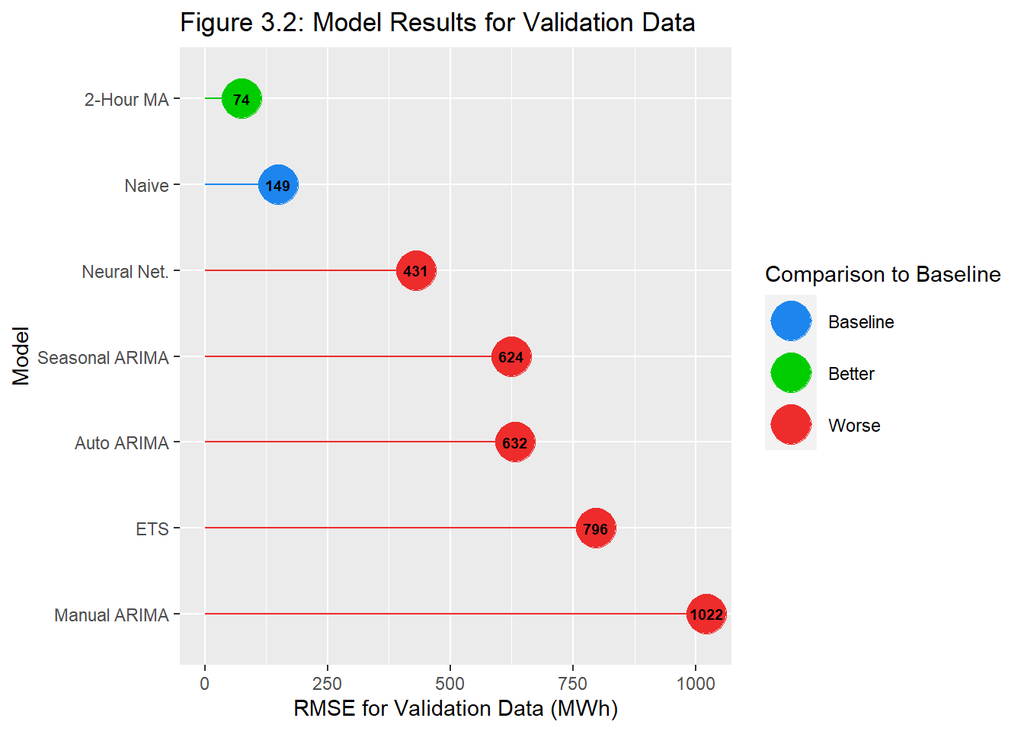

```r
ggplot(Results_df, aes(x = reorder(Model, -Val_RMSE), y = Val_RMSE, color = BaselineComp_val)) +
  geom_segment(aes(x=reorder(Model, -Val_RMSE), xend = reorder(Model, -Val_RMSE), y = 0, yend = Val_RMSE)) +
  scale_color_manual(values = c("dodgerblue2", "green3", "firebrick2")) +
  geom_point(size = 9) + coord_flip() + labs(color = "Comparison to Baseline") +
  ylab("RMSE for Validation Data (MWh)") + ggtitle("Figure 3.2: Model Results for Validation Data") + xlab("Model") + geom_text(aes(label = round(Val_RMSE)), color = "black", size = 2.5, fontface = "bold")
```